# Relationships among Personality Traits by Damian Satterthwaite-Phillips

## Model Building (Approach #1)

We now build a linear model to predict the (transformed) E (Extroversion) Score, using the other (transformed) personality scores, race, (transformed) age, engnat, gender, hand, source, and country as the predictors, but first look at the relationship of E scores to other variables to look for potential non-linear relationships:

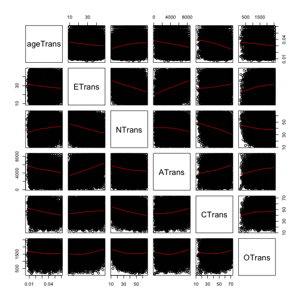

```r
variablesOfInterest <- names(big5)[63:68]
pairs(big5[, variablesOfInterest], panel=panel.smooth)
```

```r
# All relationships with E as the response (the second row of the pairs graphs) appear more or less
# linear, with the exception of O (cognitive/imaginative), which apears to have a nonlinear
# relationship, so we add a quadratic term to the model (I(OTrans^2)), as well as interaction terms
# between predictors.  In the lm() syntax, when a group of predictors are followed by "^n", the model
# includes all n-way interactions between the enclosed variables.  Hence, in the model below, all
# possible interactions between the various personality traits and age (all continuous variables) are
# considered.
# Also: to simplify, I remove entries with missing data:
complete <- big5[complete.cases(big5), ]
fullModel <- lm( ETrans ~ race + engnat + gender + hand + source + country +
                 (age + NTrans + ATrans + CTrans + OTrans + I(OTrans^2))^6, data=complete )
summary(fullModel)
```

```
##
## Call:
## lm(formula = ETrans ~ race + engnat + gender + hand + source +
##     country + (age + NTrans + ATrans + CTrans + OTrans + I(OTrans^2))^6,
##     data = complete)
##
## Residuals:
##      Min       1Q   Median       3Q      Max
## -26.8519  -5.6720   0.1335   5.6087  26.3128
##
## Coefficients:
##                                               Estimate Std. Error t value
## (Intercept)                                  3.346e+01  8.654e+01   0.387
## raceArctic                                   2.617e+00  2.231e+00   1.173
## raceEuropean                                -6.572e-01  2.347e-01  -2.800
## raceIndian                                   3.055e-01  3.692e-01   0.827
## raceMidEastern                               7.171e-01  4.489e-01   1.598
## raceNAfrican                                -4.361e-02  4.620e-01  -0.094
## raceAustrNative                              1.774e+00  1.699e+00   1.044
## raceNatAmerican                              2.563e-01  6.108e-01   0.420
## raceNEAsian                                  3.283e-01  6.413e-01   0.512
## racePacific                                  5.766e-01  1.044e+00   0.552
## raceSEAsian                                 -3.053e-01  3.402e-01  -0.897
## raceWAfrican                                -1.966e-01  5.973e-01  -0.329
## raceOther                                    5.100e-01  2.744e-01   1.859
## engnatno                                     7.619e-02  1.882e-01   0.405
## genderfemale                                 7.572e-01  1.277e-01   5.930
## genderother                                 -3.583e+00  8.287e-01  -4.324
## handleft                                    -1.635e-01  2.044e-01  -0.800
## handambi                                    -5.011e-01  3.819e-01  -1.312
## sourceGoogle                                 4.151e-01  1.579e-01   2.629
## sourceFacebook                               1.198e+00  4.765e-01   2.515
## sourceEdu                                    1.650e+00  7.073e-01   2.333
## sourceother                                  1.166e+00  1.624e-01   7.179
## country(nu                                   4.288e+00  7.977e+00   0.537
## countryA1                                    4.740e+00  8.450e+00   0.561
## countryA2                                    2.123e+00  8.453e+00   0.251
## countryAE                                    4.885e+00  8.008e+00   0.610
## countryAG                                    3.111e+00  1.127e+01   0.276
## countryAL                                    4.028e+00  8.291e+00   0.486
```

[output cut: 448 more lines]

```
## NTrans:CTrans:OTrans:I(OTrans^2)             0.96728
## ATrans:CTrans:OTrans:I(OTrans^2)             0.43794
## age:NTrans:ATrans:CTrans:OTrans              0.44260
## age:NTrans:ATrans:CTrans:I(OTrans^2)         0.55727
## age:NTrans:ATrans:OTrans:I(OTrans^2)         0.78619
## age:NTrans:CTrans:OTrans:I(OTrans^2)         0.40479
## age:ATrans:CTrans:OTrans:I(OTrans^2)         0.73427
## NTrans:ATrans:CTrans:OTrans:I(OTrans^2)      0.73194
## age:NTrans:ATrans:CTrans:OTrans:I(OTrans^2)  0.62926
## ---
## Signif. codes:  0 '***' 0.001 '**' 0.01 '*' 0.05 '.' 0.1 ' ' 1
##
## Residual standard error: 7.957 on 19055 degrees of freedom
## Multiple R-squared:  0.1983, Adjusted R-squared:  0.1882
## F-statistic: 19.56 on 241 and 19055 DF,  p-value: < 2.2e-16
```

```r
# Not all predictors are significant, so we remove predictors that are not informative using the
# step() function.  (This function adds and/or removes predictors iteratively and calcualtes the
# AIC or Akaike Information Criterion at each iteration, and returns the model with the best (lowest)
# AIC value)
reducedModel <- step(fullModel, direction='both', trace=0) # setting trace=1 prints results at each
                                                           # iteration
summary(reducedModel)
```

```
##
## Call:
## lm(formula = ETrans ~ race + gender + source + age + NTrans +
##     ATrans + CTrans + OTrans + I(OTrans^2) + age:NTrans + age:ATrans +
##     age:CTrans + age:OTrans + age:I(OTrans^2) + NTrans:ATrans +
##     NTrans:CTrans + NTrans:OTrans + NTrans:I(OTrans^2) + ATrans:CTrans +
##     ATrans:OTrans + ATrans:I(OTrans^2) + CTrans:OTrans + CTrans:I(OTrans^2) +
##     OTrans:I(OTrans^2) + age:NTrans:ATrans + age:NTrans:CTrans +
##     age:NTrans:OTrans + age:NTrans:I(OTrans^2) + age:ATrans:CTrans +
##     age:ATrans:OTrans + age:ATrans:I(OTrans^2) + age:CTrans:OTrans +
##     age:CTrans:I(OTrans^2) + age:OTrans:I(OTrans^2) + NTrans:ATrans:CTrans +
##     NTrans:ATrans:OTrans + NTrans:ATrans:I(OTrans^2) + NTrans:CTrans:OTrans +
##     NTrans:CTrans:I(OTrans^2) + NTrans:OTrans:I(OTrans^2) + ATrans:CTrans:OTrans +
##     ATrans:CTrans:I(OTrans^2) + ATrans:OTrans:I(OTrans^2) + CTrans:OTrans:I(OTrans^2) +
##     age:NTrans:ATrans:CTrans + age:NTrans:ATrans:OTrans + age:NTrans:ATrans:I(OTrans^2) +
##     age:NTrans:CTrans:OTrans + age:NTrans:OTrans:I(OTrans^2) +
##     age:ATrans:CTrans:OTrans + age:ATrans:CTrans:I(OTrans^2) +
##     age:ATrans:OTrans:I(OTrans^2) + age:CTrans:OTrans:I(OTrans^2) +
##     NTrans:ATrans:CTrans:OTrans + NTrans:ATrans:CTrans:I(OTrans^2) +
##     NTrans:ATrans:OTrans:I(OTrans^2) + NTrans:CTrans:OTrans:I(OTrans^2) +
##     ATrans:CTrans:OTrans:I(OTrans^2) + age:NTrans:ATrans:OTrans:I(OTrans^2) +
##     age:ATrans:CTrans:OTrans:I(OTrans^2) + NTrans:ATrans:CTrans:OTrans:I(OTrans^2),
##     data = complete)
##
## Residuals:
##      Min       1Q   Median       3Q      Max
## -27.2612  -5.6657   0.1262   5.7382  26.4697
##
## Coefficients:
##                                           Estimate Std. Error t value
## (Intercept)                             -6.885e+01  4.953e+01  -1.390
## raceArctic                               3.038e+00  2.229e+00   1.363
## raceEuropean                            -2.733e-01  2.271e-01  -1.203
## raceIndian                               1.058e+00  2.998e-01   3.531
## raceMidEastern                           9.155e-01  4.157e-01   2.203
## raceNAfrican                            -4.329e-02  4.552e-01  -0.095
## raceAustrNative                          2.449e+00  1.686e+00   1.453
## raceNatAmerican                          2.862e-01  6.071e-01   0.471
## raceNEAsian                              6.384e-01  6.214e-01   1.027
## racePacific                              7.576e-01  1.020e+00   0.742
```

[output cut: 136 more lines]

```
## age:CTrans:OTrans:I(OTrans^2)           1.17e-05 ***
## NTrans:ATrans:CTrans:OTrans             0.326137
## NTrans:ATrans:CTrans:I(OTrans^2)        0.165875
## NTrans:ATrans:OTrans:I(OTrans^2)        0.011689 *
## NTrans:CTrans:OTrans:I(OTrans^2)        0.085549 .
## ATrans:CTrans:OTrans:I(OTrans^2)        0.014654 *
## age:NTrans:ATrans:OTrans:I(OTrans^2)    0.045129 *
## age:ATrans:CTrans:OTrans:I(OTrans^2)    0.001064 **
## NTrans:ATrans:CTrans:OTrans:I(OTrans^2) 0.079839 .
## ---
## Signif. codes:  0 '***' 0.001 '**' 0.01 '*' 0.05 '.' 0.1 ' ' 1
##
## Residual standard error: 7.973 on 19220 degrees of freedom
## Multiple R-squared:  0.1882, Adjusted R-squared:  0.185
## F-statistic: 58.63 on 76 and 19220 DF,  p-value: < 2.2e-16
```

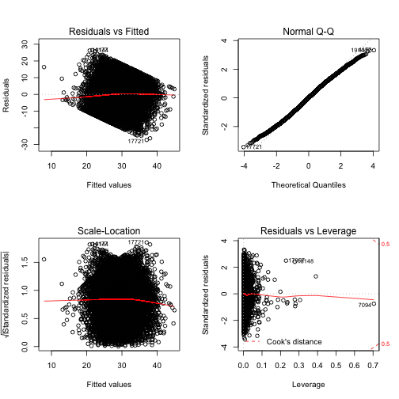

```r
# Also, look at model diagnostic plots to see how well the model fits assumptions:
par(mfrow=c(2, 2))
plot(reducedModel)
```

```r
par(mfrow=c(1, 1))
# In general, the model is "well-behaved"... residuals are roughly normally distributed (upper right),
# and more or less constant (upper and lower left), and there are no outliers that are having a
# disproportionate effect on the model (lower right)... so we can be reasonably confident that are
# model is not systematically biased.
# Note that neither country, handedness or whether English was the respondent's native language
# appeared in the reduced model, indicating that these variables did not have a significant effect on
# extroversion.
# BUT... it would be nice to be able to determine how well the model does at predicting new data so....
```

## Model Building (Approach #2)

```r
# The approach here is to use 80% of the data to build the model, and then use that model to predict
# the values of the remaining 20% of the data, and measure how well the predicted E scores match up
# with the observed E scores
records <- dim(complete)[1]
nSamples <- as.integer(0.8 * records)
sampleRecords <- sample(1:records, nSamples)

devSet <- complete[sampleRecords, ]
testSet <- complete[-sampleRecords, ]

fullModel <- lm( ETrans ~ race + engnat + gender + hand + source +
                 (age + NTrans + ATrans + CTrans + OTrans)^5, data=devSet )
reducedModel <- step(fullModel, direction='both', trace=0)
summary(reducedModel)
```

```
##
## Call:
## lm(formula = ETrans ~ race + engnat + gender + source + age +
##     NTrans + ATrans + CTrans + OTrans + age:NTrans + age:ATrans +
##     age:CTrans + age:OTrans + NTrans:ATrans + NTrans:CTrans +
##     NTrans:OTrans + ATrans:CTrans + ATrans:OTrans + CTrans:OTrans +
##     age:NTrans:ATrans + age:NTrans:CTrans + age:NTrans:OTrans +
##     age:ATrans:CTrans + age:ATrans:OTrans + age:CTrans:OTrans +
##     NTrans:ATrans:OTrans + NTrans:CTrans:OTrans + ATrans:CTrans:OTrans +
##     age:NTrans:ATrans:OTrans + age:NTrans:CTrans:OTrans + age:ATrans:CTrans:OTrans,
##     data = devSet)
##
## Residuals:
##      Min       1Q   Median       3Q      Max
## -27.7804  -5.6989   0.1619   5.7443  26.4258
##
## Coefficients:
##                            Estimate Std. Error t value Pr(>|t|)
## (Intercept)               4.785e+01  1.146e+01   4.174 3.00e-05 ***
## raceArctic                3.676e+00  2.540e+00   1.447  0.14791
## raceEuropean             -2.231e-01  2.528e-01  -0.882  0.37756
## raceIndian                9.497e-01  3.398e-01   2.795  0.00520 **
## raceMidEastern            6.894e-01  4.650e-01   1.483  0.13818
## raceNAfrican             -1.636e-01  5.164e-01  -0.317  0.75136
## raceAustrNative           2.465e+00  1.808e+00   1.363  0.17285
## raceNatAmerican           3.889e-01  6.549e-01   0.594  0.55268
## raceNEAsian               8.550e-01  6.817e-01   1.254  0.20975
## racePacific               5.439e-01  1.178e+00   0.462  0.64442
## raceSEAsian              -5.147e-01  3.227e-01  -1.595  0.11074
## raceWAfrican              1.526e-01  6.149e-01   0.248  0.80405
## raceOther                 7.887e-01  2.996e-01   2.633  0.00848 **
## engnatno                  2.208e-01  1.476e-01   1.496  0.13467
## genderfemale              7.227e-01  1.414e-01   5.110 3.27e-07 ***
## genderother              -2.920e+00  9.087e-01  -3.214  0.00131 **
## sourceGoogle              2.666e-01  1.740e-01   1.532  0.12550
## sourceFacebook            1.448e+00  5.163e-01   2.804  0.00506 **
## sourceEdu                 9.333e-01  8.062e-01   1.158  0.24703
## sourceother               1.047e+00  1.784e-01   5.870 4.44e-09 ***
## age                      -7.134e-01  4.225e-01  -1.689  0.09130 .
## NTrans                   -2.820e-01  2.029e-01  -1.390  0.16462
```

[output cut: 16 more lines]

```
## age:ATrans:CTrans        -2.428e-06  9.270e-07  -2.619  0.00883 **
## age:ATrans:OTrans        -7.215e-08  3.637e-08  -1.984  0.04729 *
## age:CTrans:OTrans        -3.913e-06  4.494e-06  -0.871  0.38398
## NTrans:ATrans:OTrans     -3.445e-08  1.473e-08  -2.339  0.01936 *
## NTrans:CTrans:OTrans      1.340e-06  2.326e-06   0.576  0.56438
## ATrans:CTrans:OTrans     -9.657e-09  1.537e-08  -0.628  0.52985
## age:NTrans:ATrans:OTrans  7.200e-10  5.025e-10   1.433  0.15195
## age:NTrans:CTrans:OTrans -1.101e-07  7.543e-08  -1.459  0.14451
## age:ATrans:CTrans:OTrans  9.438e-10  5.402e-10   1.747  0.08064 .
## ---
## Signif. codes:  0 '***' 0.001 '**' 0.01 '*' 0.05 '.' 0.1 ' ' 1
##
## Residual standard error: 7.989 on 15390 degrees of freedom
## Multiple R-squared:  0.183,  Adjusted R-squared:  0.1806
## F-statistic: 74.94 on 46 and 15390 DF,  p-value: < 2.2e-16
```

```r
# Before we even put our model to the test, notice the multiple R-squared value of [0.1827] indicating
# that the model explains [18.27%] of the variance... which means the remaining variance is not
# explained by any of our variables... Hence, even before testing we might not expect the model to
# perform very well.
predictions <- predict.lm(fullModel, newdata=testSet)
modErrors <- testSet$ETrans - predictions

range(complete$ETrans)
```

```
## [1]  9.772372 48.081754
```

```r
range(predictions)
```

```
## [1]  0.6118529 43.5776086
```

```r
max(complete$ETrans) - min(complete$ETrans)
```

```
## [1] 38.30938
```

```r
perfSummary <- cbind( quantile( complete$ETrans, prob=c( 0, 0.01, 0.05, 0.1, 0.25, 0.5, 0.75, 0.9,
                                                         0.95, 0.99, 1 ) ),
                      quantile( predictions, prob=c( 0, 0.01, 0.05, 0.1, 0.25, 0.5, 0.75, 0.9, 0.95,
                                                     0.99, 1 ) ),
                      quantile( modErrors, prob=c( 0, 0.01, 0.05, 0.1, 0.25, 0.5, 0.75, 0.9, 0.95,
                                                   0.99, 1 ) ))
colnames(perfSummary) <- c('Observed', 'Predicted', 'Error')
perfSummary
```

```
##       Observed  Predicted       Error
## 0%    9.772372  0.6118529 -28.6384819
## 1%   10.739369 20.8411999 -17.6382759
## 5%   14.599243 23.1330299 -12.9472321
## 10%  17.487180 24.3721684 -10.2053156
## 25%  22.290025 26.3443716  -5.3630462
## 50%  28.996798 28.7873850   0.3235132
## 75%  35.687794 31.3771329   5.9704276
## 90%  40.459154 33.9843231  10.7596239
## 95%  43.319196 35.5963491  13.1055686
## 99%  47.129640 38.4206847  17.5605480
## 100% 48.081754 43.5776086  34.8097284
```

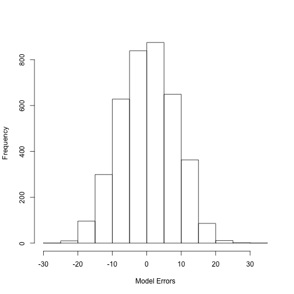

```r
hist(modErrors, main='', xlab='Model Errors')
```

```r
options(warn = 0)   # Don't forget to turn warnings back on
```

## Final Plots and Summary

```
## geom_smooth: method="auto" and size of largest group is >=1000, so using gam with formula: y ~ s(x, bs = "cs"). Use 'method = x' to change the smoothing method.
```

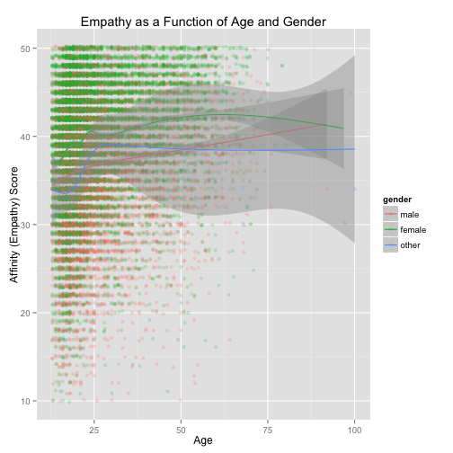

```r
ggplot(aes(x=jitter(age), y=jitter(AScore)), data=subset(big5, !is.na(ageTrans) & !is.na(gender))) +
    geom_point(alpha=0.2, aes(color=gender)) +
    geom_smooth(aes(col=gender)) +
    xlab('Age') +
    ylab('Affinity (Empathy) Score') +
    ggtitle('Empathy as a Function of Age and Gender')
```

```
## geom_smooth: method="auto" and size of largest group is >=1000, so using gam with formula: y ~ s(x, bs = "cs"). Use 'method = x' to change the smoothing method.
```

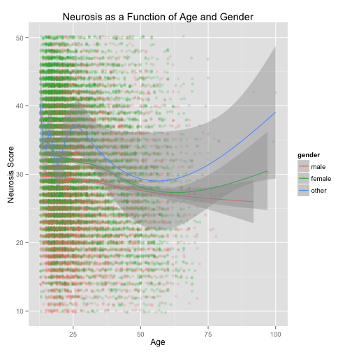

```r
ggplot(aes(x=jitter(age), y=jitter(NScore)), data=subset(big5, !is.na(ageTrans) & !is.na(gender))) +
    geom_point(alpha=0.2, aes(color=gender)) +
    geom_smooth(aes(col=gender)) +
    xlab('Age') +
    ylab('Neurosis Score') +
    ggtitle('Neurosis as a Function of Age and Gender')
```

```
## geom_smooth: method="auto" and size of largest group is >=1000, so using gam with formula: y ~ s(x, bs = "cs"). Use 'method = x' to change the smoothing method.
```

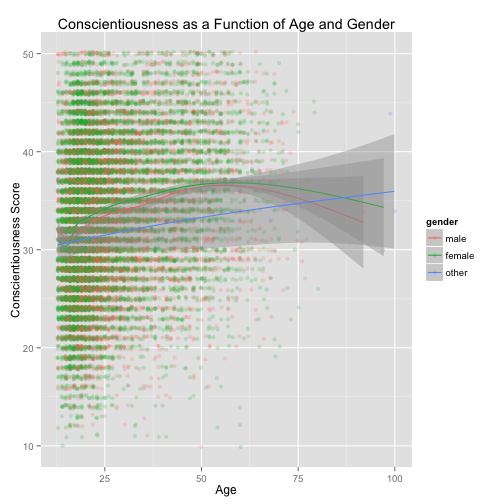

```r
ggplot(aes(x=jitter(age), y=jitter(CScore)), data=subset(big5, !is.na(ageTrans) & !is.na(gender))) +
    geom_point(alpha=0.2, aes(color=gender)) +
    geom_smooth(aes(col=gender)) +
    xlab('Age') +
    ylab('Conscientiousness Score') +
    ggtitle('Conscientiousness as a Function of Age and Gender')
```

## Reflection

Looking at the final plots above, it is apparent that both gender and age account for noticeable differences in personality traits. Furthermore, trends with respect to age are encouraging.

Neurosis also shows noticeable differences by gender, with males being the least neurotic, and females and other gendered people being somewhat more neurotic. However for all genders, there is a general tendency toward decreasing neurosis with age. While both females and others show an upward curve for more advanced ages (~ age 60 and above), there are few data points in this part of the graph, that this apparent effect may be due to sample bias (too few data points), and the wide grey error indicators similarly indicate that this upward trend may not be real, but merely a relic of the few data points in the sample.

Finally, the 3rd graph also gives an encouraging message. Over a lifetime, males and females tend to be very similarly conscientious, and others perhaps somewhat less so (though notice that error bars overlap over nearly the entire graph, suggesting no significant differences by gender). In general, people of all genders tend to become more conscietious with age. As with the previous graph, there is curvature in the average behavior of elders (>55 years old), but this may again be due only to the small sample size for this age range.

However, as noted in the “Model Building” section above, race sometimes plays a role in personality traits, and there are many complicated interactions between variables as well. Finally, although these variables do account for some of the variation we see in personality traits, as the model for extroversion indicates, even these variables and their interactions collectively only account for a small amount of the variation seen in personality traits (<20% in the case of extroversion), so there must be other variables that account for the remainder of the variation that were not considered in these analyses.